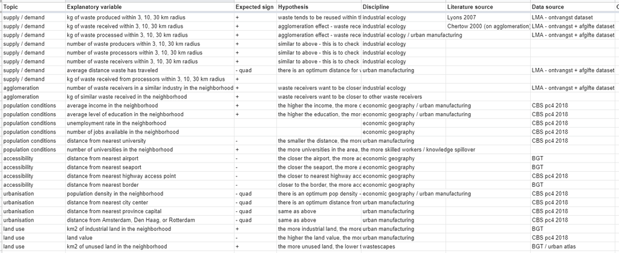

```python
from IPython.display import Image
Image("../images/explanatory-variable_options.png", width=1250)
```

# Explanatory variable preparer

In this notebook, we will make prepare explanatory variables by doing the the following:

- take in all datasources required to compute explanatory variables
- compute explanatory variables
- aggregates all explanatory vairables into pc4 geo-dataframe
- saves geodataframe as a shpfile

[List of potential explanatory variables](https://docs.google.com/spreadsheets/d/1bLXX-tXXx5Rx7kTC0yI85RmJrlsrm5QRq2ndD0rWvEo/edit#gid=221637185) extracted from literature and previous research

```python
# import modules
import os
import pandas as pd
import geopandas as gpd
import numpy as np
%matplotlib inline
import matplotlib.pyplot as plt
import feather
import plotly.express as px
import psutil
import seaborn as sn
```

## Read and clean datasources

Here we create prepare a dataframe that has the explanatory variables. The explanatory variables will come from various datasets (such as CBS, BGT, UrbanAtlas). We can find these suitable variables through literature review.

### Flow-related data

Here we extract data from datasets about material flows per postcode. This type of data can be found in the following datasets:

- afgifte dataset (kg waste received, processed, distance traveled)
- ontvangst dataset (kg waste produced, processed)

**Looking at afgifte dataset**

```python
# prep dff
af = feather.read_dataframe('../data/lma/af_2019-2020_valid.feather') # af - afgifte dataset
af = af[['herNaam', 'herPostcode', 'eaNaam', 'eaPostcode', 'mat', 'matDesc', 'vmc', 'vmcDesc', 'sbiSec', 'sbiSecDesc', 'kg']]
af.rename(columns={'eaPostcode': 'eaPc',
                   'herPostcode': 'verPc',
                   'herNaam': 'verNaam'
                  }, inplace=True)
af.eaPc = af.eaPc.str[:4]
af.verPc = af.verPc.str[:4]

# format name columns
af.verNaam = af.verNaam.str.lower().replace(r'[.,/\"\'-]', '', regex=True).replace(u'\xa0', u' ')
af.eaNaam = af.eaNaam.str.lower().replace(r'[.,/\"\'-]', '', regex=True).replace(u'\xa0', u' ')
af.matDesc = af.matDesc.str[:50]

# display
af.head()
```

|  | verNaam | verPc | eaNaam | eaPc | mat | matDesc | vmc | vmcDesc | sbiSec | sbiSecDesc | kg |
| --- | --- | --- | --- | --- | --- | --- | --- | --- | --- | --- | --- |
| 0 | dbg bouw en reststoffen | 9723 | brabantcreative infra solutions bv | 5301 | 12.6 | ESV - Mineral wastes: Soils | C04 | Immobiliseren voor hergebruik | F | Bouwnijverheid | 980340 |
| 1 | poelman zandhandel bv | 9865 | bestratingsbedrijf w de boer | 9222 | 12.6 | ESV - Mineral wastes: Soils | B05 | Overig inzetten als grondstof | F | Bouwnijverheid | 15860 |
| 2 | poelman zandhandel bv | 9865 | christiaan van der wal | 9243 | 12.1 | ESV - Mineral wastes: Construction and demolit... | B05 | Overig inzetten als grondstof | F | Bouwnijverheid | 686240 |
| 3 | poelman zandhandel bv | 9865 | gebroeders kok hodn landbouwbedrijf gebroeders... | 9243 | 12.1 | ESV - Mineral wastes: Construction and demolit... | B05 | Overig inzetten als grondstof | A | Landbouw, bosbouw en visserij | 121360 |
| 4 | poelman zandhandel bv | 9865 | gebroeders kok hodn landbouwbedrijf gebroeders... | 9243 | 12.1 | ESV - Mineral wastes: Construction and demolit... | B05 | Overig inzetten als grondstof | A | Landbouw, bosbouw en visserij | 230220 |

```python
# check for null values in columns
for column in af.columns:
    numNull = len(af[af[column].isna()])
    if numNull > 0:
        print('{} has null values.'.format(column))
        print('# rows with null values for {}: {}'.format(column, numNull))
```

```
verNaam has null values.
# rows with null values for verNaam: 10
verPc has null values.
# rows with null values for verPc: 60
eaPc has null values.
# rows with null values for eaPc: 2
```

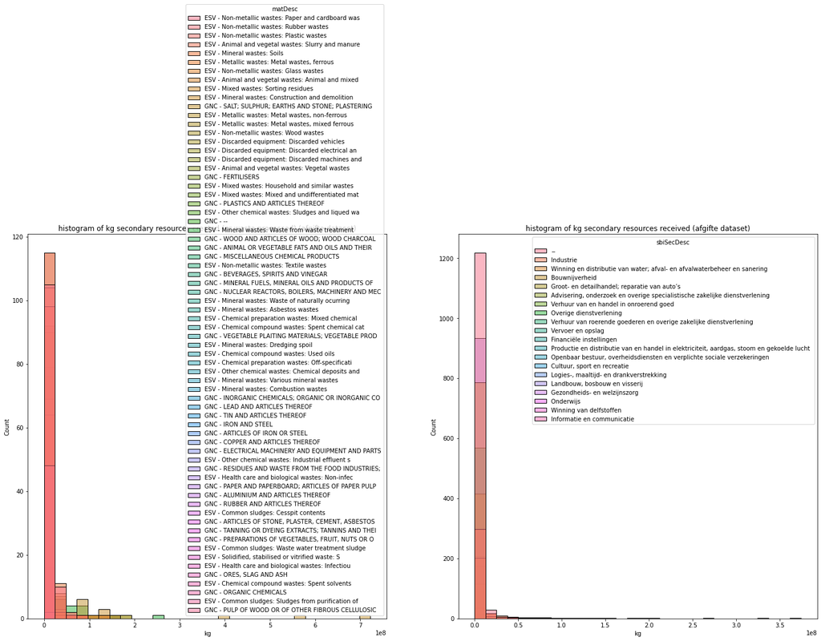

```python
# kg waste received for each industry type, for each postcode
afReInd = af.groupby(['eaPc', 'sbiSec', 'sbiSecDesc']).sum().reset_index() # attention: some rows have null values for eaPc4, so they are dropped during groupby.
afProMat = af.groupby(['verPc', 'mat', 'matDesc']).sum().reset_index() # attention: some rows have null values for herPc4, so they are dropped during groupby.
fig, ax = plt.subplots(1,2, figsize=(12*2,12))
sn.histplot(data=afProMat, x='kg', bins=30, ax=ax[0], hue='matDesc')
ax[0].set_title('histogram of kg secondary resources created (or waste processed) (afgifte dataset)')
sn.histplot(data=afReInd, x='kg', bins=30, ax=ax[1], hue='sbiSecDesc')
ax[1].set_title('histogram of kg secondary resources received (afgifte dataset)')
plt.show()
```

**looking at ontvangst dataset**

```python
# read and clean ontvangst dataset
ont = feather.read_dataframe('../data/lma/ont_combined.feather') # ont = ontvangst dataset
ont = ont[['ontNaam', 'ontPc', 'herPc', 'verNaam', 'verPc', 'esvChap', 'esvChapDesc', 'vmc', 'vmcDesc', 'kg']]

# check out empty rows
perHer = round(ont[ont.herPc.isna()].kg.sum() / ont.kg.sum() * 100,2)
perOnt = round(ont[ont.ontPc.isna()].kg.sum() / ont.kg.sum() * 100,2)
perBoth = round(ont[(ont.herPc.isna()) & (ont.ontPc.isna())].kg.sum() / ont.kg.sum() * 100, 2)
print('% empty rows for herPc (by weight): {}'.format(perHer))
print('% empty rows for ontPc (by weight): {}'.format(perOnt))
print('% empty rows for both her and ont Pc (by weight): {}'.format(perBoth))

# new column of herOntPc
def herOnt(row):
    if row.herPc != None:
        return row.herPc
    elif row.ontPc != None:
        return row.ontPc
    else:
        return None
ont['herPc'] = ont.apply(lambda row: herOnt(row), axis=1)
print('her and ont Pc have been combined into one column')

# drop rows
ont = ont[~ont.herPc.isna()] # with no pc (only 1% of rows by weight, so it's fine.)
ont = ont[ont.kg > 0]
ont.drop(labels=['ontPc'], axis=1, inplace=True)

# format name columns
ont.ontNaam = ont.ontNaam.str.lower()
ont.ontNaam = ont.ontNaam.str.replace(r'[.,/\"\'-]', '', regex=True)
ont.ontNaam = ont.ontNaam.str.replace(u'\xa0', u' ')
ont.verNaam = ont.verNaam.str.lower()
ont.verNaam = ont.verNaam.str.replace(r'[.,/\"\'-]', '', regex=True)
ont.verNaam = ont.verNaam.str.replace(u'\xa0', u' ')

# display
ont.head()
```

```
% empty rows for herPc (by weight): 0.0
% empty rows for ontPc (by weight): 0.12
% empty rows for both her and ont Pc (by weight): 0.0
her and ont Pc have been combined into one column
```

|  | ontNaam | herPc | verNaam | verPc | esvChap | esvChapDesc | vmc | vmcDesc | kg |
| --- | --- | --- | --- | --- | --- | --- | --- | --- | --- |
| 0 | enexis bv | 9741 | dbg bouw en reststoffen | 9723 | 12.6 | Mineral wastes - Soils | A02 | Overslag / opbulken | 86010 |
| 1 | gemeente bedum | 9781 | dbg bouw en reststoffen | 9723 | 12.6 | Mineral wastes - Soils | A02 | Overslag / opbulken | 89000 |
| 2 | gemeente groningen | 9712 | dbg bouw en reststoffen | 9723 | 12.1 | Mineral wastes - Construction and demolition w... | A02 | Overslag / opbulken | 52960 |
| 3 | gemeente groningen | 9712 | dbg bouw en reststoffen | 9723 | 12.1 | Mineral wastes - Construction and demolition w... | A02 | Overslag / opbulken | 63490 |
| 4 | van wijnen projectontwikkeling noord bv | 9732 | dbg bouw en reststoffen | 9723 | 12.6 | Mineral wastes - Soils | A02 | Overslag / opbulken | 100140 |

```python
# check for null values in columns
for column in ont.columns:
    numNull = len(ont[ont[column].isna()])
    if numNull > 0:
        print('# rows with null values for {}: {}'.format(column, numNull))

perNa = round(ont[ont.isna().any(axis=1)].kg.sum() / ont.kg.sum() * 100, 2)
print('% missing rows (by weight): {}'.format(perNa))

if perNa <= 5:
    print('no need to fix null values, percentage is small enough')
else:
    print('significant number of null values, need to fix!')
```

```
# rows with null values for ontNaam: 5
# rows with null values for verNaam: 793
# rows with null values for verPc: 2441
% missing rows (by weight): 2.33
no need to fix null values, percentage is small enough
```

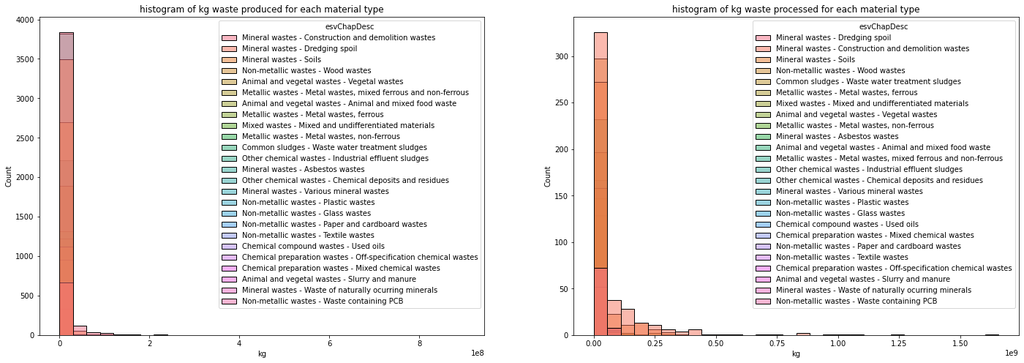

```python
# kg waste produced for each material type, for each postcode
ontProdMat = ont.groupby(['herPc', 'esvChap', 'esvChapDesc']).sum().reset_index().sort_values('kg', ascending=False)

# kg waste processed for each material type, for each postcode
ontProcMat = ont.groupby(['verPc', 'esvChap', 'esvChapDesc']).sum().reset_index().sort_values('kg', ascending=False)

# plot distribution of both
fig, ax = plt.subplots(1,2, figsize=(12*2,8))
sn.histplot(data=ontProdMat, x='kg', bins=30, hue='esvChapDesc', ax=ax[0])
ax[0].set_title('histogram of kg waste produced for each material type')
sn.histplot(data=ontProcMat, x='kg', bins=30, hue='esvChapDesc', ax=ax[1])
ax[1].set_title('histogram of kg waste processed for each material type')
plt.show()
```

```python
# comparing weights from ont and af dataset
print('total kg in ont dataset: {}'.format(ont.kg.sum()))
print('total kg in af dataset: {}'.format(af.kg.sum()))
print('af dataset is {}% of ont dataset'.format(round(af.kg.sum() / ont.kg.sum() * 100, 2)))
```

```
total kg in ont dataset: 58232907394
total kg in af dataset: 12350571449
af dataset is 21.21% of ont dataset
```

The afgifte dataset is significantly smaller than the ontvangst dataset - af is only 20% of ont. Here are the reasons why this is the case (I think):

- the ontvangst dataset might have some repeated flows. Let's say 100kg of wood is produced by producer A, then is processed by processor B, and then is further processed by processor C. This flow is recorded as two rows on the the ontvangst dataset. So 100kg of wood in reality shows up as 200kg of wood on the dataset.
  - the first row is: producer A --> processor B || wood || 100kg
  - the second row is: processor B --> processor C || wood || 100kg
- not all waste flows end up in the afgifte dataset - only flows that end up with non-waste processors show up in the afgifte dataset. So flows that end of in the incinerator, for example, don't end up in the afgifte dataset because incinerators are counted as waste processors as well.

**So how should I map and calculate the producers, processors, and receivers of waste?**

- waste producing PCs are located in the 'herPc' column of the ont dataset.
  - However, there's no way of knowing if the waste produced is 'real' (waste produced immediately after use like municipal waste), or already 'processed' (waste that has already gone through a waste processor and is on the way to be further processed by another waste company).
  - Also, one waste flow could be counted twice in the herPc column, see first point in previous paragraph.
- waste processing PCs are located in the 'herPc' and 'verPc' columns of the ontvangst dataset, as well as the 'verPc' columns of the afgifte dataset.
  - again, it is a challenge to distinguish waste producers and waste processors in the 'herPc' column in the ontvangst dataset.
  - also, could there be a chance that the 'verPc' column in the ontvangst dataset is repeated in the 'verPc' column of the afgifte dataset?
- waste receiving PCs are more straight forward - they are located in the 'eaPc' column of the afgifte dataset.

**Challenges for differentiating producers and processors** Extracting waste receivers is very straightforward, but differentiating between waste producers and processors is more difficult, see paragraph above. In order to differentiate between waste producers and processors, we need to solve the following problems:

- find out which herPcs are waste producers, and which are waste processors. One way to do this is to see if the herkomst name also appears as a verwerker in the ontvangst dataset.
- make sure that one waste flow is not counted twice.
  - However you could argure that this doesn't necessarily matter if you take an 'industry' and 'territorial' perspective. Let's say that 100kg of wood is produced in postcode A, processed in postcode B, then further processed in postcode C. If you care about the 'processing power' of postcodes in the Netherlands, then you would want a record of both postcode B and C, because there were processors in both pc B and C, even if they were processing the same flow of waste.

```python
# find names in ontNaam that also appear in verNaam
ontOntNaams = list(ont.ontNaam.unique())
ontVernaams = list(ont.verNaam.unique())

ontDupNaams = []
for name in ontOntNaams:
    if name in ontVernaams:
        ontDupNaams.append(name)

perDup = round(ont[ont.ontNaam.isin(ontDupNaams)].kg.sum() / ont.kg.sum() * 100, 2)
print('number of ontNaams that also appear in verNaam: {}'.format(len(ontDupNaams)))
print('% duplicated rows by weight: {}'.format(perDup))
```

```
number of ontNaams that also appear in verNaam: 582
% duplicated rows by weight: 14.02
```

Here, we found that there are 582 waste producers (ontdoeners) who also appear in the ontvangst dataset at waste processors (verwerkers). But what does it actually mean when the same name appears in both the ontNaam and verNaam column? Are these names producers, or processors?

**Here's my guess** (see sketch below): companies that appear both as ontdoeners and verwerkers are actually verwerkers. They sometimes appear as ontdoeners because they sometimes give their processed waste to another waste company for further processing. So, in order to make a dataframe for processors, we just have to look at the verwerker columns of the ontvangst dataset. However, to make a dataframe for producers, we should look at the ontdoener column of the ontvangst dataset, but get rid of the names that also appear in the verwerker column. (image below gives a good summary of this)

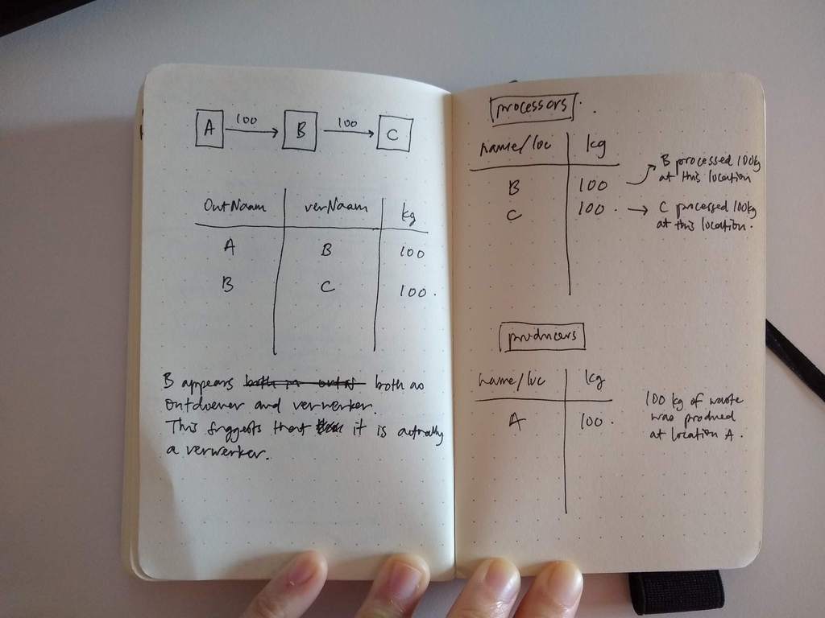

```python
Image("../images/ontdoener-vs-verwerker.jpg", width=600)
```

#### Making geodataframes for kg produced, processed, and received per postcode in the Netherlands

```python
# read pc4 shpfile
pc4 = gpd.read_file('../data/spatial-data/nl_pc4.shp')
pc4 = pc4[['PC4', 'geometry']]
pc4.rename(columns={'PC4': 'pc'}, inplace=True)
print('pc4 shapfile read')
print(pc4.shape)
```

```
pc4 shapfile read
(4068, 2)
```

```python
# make producers dataframe
dfProd = ont.copy()
dfProd = dfProd[~dfProd.verNaam.isin(ontDupNaams)]
print('total waste produced: {} million tons'.format(round(dfProd.kg.sum() / 1000000 / 1016, 2))) # tons = kg / 1016
print('% waste produced (and not processed) in ontvangst dataset: {}'.format(round(dfProd.kg.sum() / ont.kg.sum() * 100, 2)))
dfProd.rename(columns={'ontNaam': 'name', 'herPc': 'pc', 'esvChap': 'mat', 'esvChapDesc': 'matDesc'}, inplace=True)
dfProd.matDesc = 'ESV - ' + dfProd.matDesc
dfProd['flowType'] = 'waste producer'
dfProd = dfProd[['name', 'flowType', 'pc', 'mat', 'matDesc', 'vmc', 'vmcDesc', 'kg']]

dfProd['logkg'] = dfProd.kg.map(lambda x: np.log10(x) if x != 0 else 0)

dfProd.head()
```

```
total waste produced: 29.28 million tons
% waste produced (and not processed) in ontvangst dataset: 51.08
```

|  | name | flowType | pc | mat | matDesc | vmc | vmcDesc | kg | logkg |
| --- | --- | --- | --- | --- | --- | --- | --- | --- | --- |
| 0 | enexis bv | waste producer | 9741 | 12.6 | ESV - Mineral wastes - Soils | A02 | Overslag / opbulken | 86010 | 4.934549 |
| 1 | gemeente bedum | waste producer | 9781 | 12.6 | ESV - Mineral wastes - Soils | A02 | Overslag / opbulken | 89000 | 4.949390 |
| 2 | gemeente groningen | waste producer | 9712 | 12.1 | ESV - Mineral wastes - Construction and demoli... | A02 | Overslag / opbulken | 52960 | 4.723948 |
| 3 | gemeente groningen | waste producer | 9712 | 12.1 | ESV - Mineral wastes - Construction and demoli... | A02 | Overslag / opbulken | 63490 | 4.802705 |
| 4 | van wijnen projectontwikkeling noord bv | waste producer | 9732 | 12.6 | ESV - Mineral wastes - Soils | A02 | Overslag / opbulken | 100140 | 5.000608 |

```python
# make processors dataframe
# extract processors from ontvangst dataset
dfProc = ont.copy()
dfProc.rename(columns={'verNaam': 'name', 'verPc': 'pc', 'esvChap': 'mat', 'esvChapDesc': 'matDesc'}, inplace=True)
dfProc = dfProc[['name', 'pc', 'mat', 'matDesc', 'vmc', 'vmcDesc', 'kg']]
dfProc.matDesc = 'ESV - ' + dfProc.matDesc

# extract processors from afgifte dataset
temp = af.copy()
temp = temp[['verNaam', 'verPc', 'mat', 'matDesc', 'vmc', 'vmcDesc', 'kg']]
temp.rename(columns={'verNaam': 'name', 'verPc': 'pc'}, inplace=True)

# combine processors from afgifte and ontvangst dataset
dfProc = pd.concat([dfProc, temp])
dfProc.fillna('--', inplace=True)

# formatting
dfProc['logkg'] = dfProc.kg.map(lambda x: np.log10(x) if x != 0 else 0)
dfProc['flowType'] = 'waste processor'
print('dropping {}% of rows due to missing pc'.format(round(dfProc[dfProc.pc == '--'].kg.sum() / dfProc.kg.sum(), 2)))
dfProc = dfProc[dfProc.pc != '--']

# display
dfProc = dfProc[['name', 'flowType', 'pc', 'mat', 'matDesc', 'vmc', 'vmcDesc', 'kg']]
print('total waste processed: {} million tons'.format(round(dfProc.kg.sum() / 1000000 / 1016, 2)))
print('% waste processed (and not produced or received) in lma dataset (both ontvangst and afgifte): {}'.format(round(dfProc.kg.sum() / (ont.kg.sum() + af.kg.sum()) * 100, 2)))
dfProc.head(3)
```

```
dropping 0.02% of rows due to missing pc
total waste processed: 68.1 million tons
% waste processed (and not produced or received) in lma dataset (both ontvangst and afgifte): 98.03
```

|  | name | flowType | pc | mat | matDesc | vmc | vmcDesc | kg |
| --- | --- | --- | --- | --- | --- | --- | --- | --- |
| 0 | dbg bouw en reststoffen | waste processor | 9723 | 12.6 | ESV - Mineral wastes - Soils | A02 | Overslag / opbulken | 86010 |
| 1 | dbg bouw en reststoffen | waste processor | 9723 | 12.6 | ESV - Mineral wastes - Soils | A02 | Overslag / opbulken | 89000 |
| 2 | dbg bouw en reststoffen | waste processor | 9723 | 12.1 | ESV - Mineral wastes - Construction and demoli... | A02 | Overslag / opbulken | 52960 |

```python
# make receivers dataframe
dfRec = af.copy()
dfRec['flowType'] = 'waste receiver'
dfRec = dfRec[['eaNaam', 'flowType', 'eaPc', 'mat', 'matDesc', 'vmc', 'vmcDesc', 'sbiSec', 'sbiSecDesc', 'kg']]
dfRec.rename(columns={'eaNaam': 'name', 'eaPc': 'pc'}, inplace=True)
dfRec['logkg'] = dfRec.kg.map(lambda x: np.log10(x) if x != 0 else 0)
dfRec.fillna('--', inplace=True)

# drop empty pcs
print('dropping {}% of rows due to missing pc'.format(round(dfRec[dfRec.pc == '--'].kg.sum() / dfRec.kg.sum(), 4)))
dfRec = dfRec[dfRec.pc != '--']

# display
print('total waste received: {} million tons'.format(round(dfRec.kg.sum() / 1000000 / 1016, 2)))
print('% waste received (and not produced or processed) in lma dataset (both ontvangst and afgifte): {}'.format(round(dfRec.kg.sum() / (ont.kg.sum() + af.kg.sum()) * 100, 2)))
dfRec.head(3)
```

```
dropping 0.0001% of rows due to missing pc
total waste received: 12.16 million tons
% waste received (and not produced or processed) in lma dataset (both ontvangst and afgifte): 17.5
```

|  | name | flowType | pc | mat | matDesc | vmc | vmcDesc | sbiSec | sbiSecDesc | kg | logkg |
| --- | --- | --- | --- | --- | --- | --- | --- | --- | --- | --- | --- |
| 0 | brabantcreative infra solutions bv | waste receiver | 5301 | 12.6 | ESV - Mineral wastes: Soils | C04 | Immobiliseren voor hergebruik | F | Bouwnijverheid | 980340 | 5.991377 |
| 1 | bestratingsbedrijf w de boer | waste receiver | 9222 | 12.6 | ESV - Mineral wastes: Soils | B05 | Overig inzetten als grondstof | F | Bouwnijverheid | 15860 | 4.200303 |
| 2 | christiaan van der wal | waste receiver | 9243 | 12.1 | ESV - Mineral wastes: Construction and demolit... | B05 | Overig inzetten als grondstof | F | Bouwnijverheid | 686240 | 5.836476 |

```python
# combining waste produced, processed, and received
dfCom = pd.concat([dfProd, dfProc, dfRec])
dfCom.fillna('--', inplace=True)
dfCom = dfCom.groupby(['pc', 'flowType', 'mat', 'matDesc', 'vmc', 'vmcDesc', 'sbiSec', 'sbiSecDesc']).sum().kg.reset_index()

# display
dfCom.head()
```

|  | pc | flowType | mat | matDesc | vmc | vmcDesc | sbiSec | sbiSecDesc | kg |
| --- | --- | --- | --- | --- | --- | --- | --- | --- | --- |
| 0 | 1000 | waste producer | 06.1 | ESV - Metallic wastes - Metal wastes, ferrous | G01 | Direct storten | -- | -- | 134480 |
| 1 | 1000 | waste producer | 12.1 | ESV - Mineral wastes - Construction and demoli... | F07 | Verbranden met terugwinnen energie (bijstoken) | -- | -- | 68940 |
| 2 | 1000 | waste producer | 12.6 | ESV - Mineral wastes - Soils | A02 | Overslag / opbulken | -- | -- | 138860 |
| 3 | 1011 | waste producer | 07.5 | ESV - Non-metallic wastes - Wood wastes | A02 | Overslag / opbulken | -- | -- | 6090 |
| 4 | 1011 | waste producer | 10.2 | ESV - Mixed wastes - Mixed and undifferentiate... | A02 | Overslag / opbulken | -- | -- | 978 |

```python
# save as feather file (doesn't make sense to save a shpfile, it's too big and takes too long)
feather.write_dataframe(dfCom, '../data/lma/flows_ont-af_combined.feather')
```

### Space-related data

Here we extract data from datasets about space, such as accessibility, density, proximity, urbanization. This type of data can be found in the following datasets:

- Open Street Map (land-use)
  - km2 of industrial land in the neighborhood
  - distance (km) to nearest industrial area
- CBS (accessibility, density)
  - population density in the neighborhood
  - distance from nearest highway access point
  - land value
  - distance to nearest urban area type
- other sources (mymaps, other websites)
  - distance from nearest airport
  - distance from nearest seaport
  - distance from nearest freight station

**Industrial land factors from open street map data**

- km2 of industrial land in the neighborhood
- distance (km) to nearest industrial area

Here we add variables from the open street map dataset. OSM data can be downloaded easily from the following websites:

- https://download.geofabrik.de/europe.html
- https://extract.bbbike.org/
- https://www.openstreetmap.org/export#map=9/52.0508/5.4959

```python
%%time
# read industrial land use data from osm
osm = gpd.read_file('../data/spatial-data/osm_nl/gis_osm_landuse_a_free_1.shp')
indland = osm[osm.fclass == 'industrial']
indland = indland.to_crs('EPSG:28992')
mp = indland.unary_union # multi-polygon of all industrial land in NL
mp = mp.buffer(0) # prevents self-intersection error

# read pc4 data
pc = gpd.read_file('../data/spatial-data/nl_pc4.shp')
pc = pc[['PC4', 'geometry']]
pc.rename(columns={'PC4': 'pc'}, inplace=True)
pc = pc.to_crs('EPSG:28992')
```

```
Wall time: 2min
```

```python
%%time
# calculate km2 industrial land for each pc
def indLand(x):
    try:
        temp = osm[osm.pc == x]
        intersection = temp.geometry.intersection(mp)
        area = intersection.area.iloc[0] / 1000000
    except:
        area = np.NaN
    return area

osm = pc.copy()
osm.geometry = osm.geometry.buffer(0) # prevents self-intersection error
osm = osm.to_crs('EPSG:28992')
osm['areaIndLand'] = osm.pc.map(lambda x: indLand(x))

# add other params
osm['areaPc'] = osm.geometry.area / 1000000 # total area of pc
osm['percIndLand'] = osm.areaIndLand / osm.areaPc * 100 # % industrial land for each pc

# display
osm.head()
```

```
Wall time: 1min 40s
```

|  | pc | geometry | areaIndLand | areaPc | percIndLand |
| --- | --- | --- | --- | --- | --- |
| 0 | 1011 | POLYGON ((122183.249 487939.201, 122183.241 48... | 0.000000 | 0.975149 | 0.000000 |
| 1 | 1012 | POLYGON ((122049.209 488210.972, 122120.438 48... | 0.000000 | 1.160333 | 0.000000 |
| 2 | 1013 | POLYGON ((120047.752 491287.512, 120402.310 49... | 2.009310 | 4.900078 | 41.005674 |
| 3 | 1014 | MULTIPOLYGON (((121228.183 489780.930, 121182.... | 0.702016 | 2.931924 | 23.943881 |
| 4 | 1015 | POLYGON ((120603.279 488589.178, 120640.375 48... | 0.000000 | 0.755428 | 0.000000 |

```python
from shapely.ops import nearest_points

# multipolygon of centroids of all industrial areas in nl
indpt = indland.geometry.centroid
indpt = indpt.geometry.unary_union

# find nearest industrial area (centroid) for each pc
def nearest(x):
    nearest = nearest_points(x, indpt)[1]
    return nearest
pcpt = osm.geometry.centroid
nearestIndPt = pcpt.map(lambda x: nearest(x))
nearestIndPt = nearestIndPt.set_crs('EPSG:28992')

# calculate distance to nearest industrial area (centroid) for each pc
osm['distInd'] = pcpt.distance(nearestIndPt) / 1000
osm['distInd'] = osm.apply(lambda row: 0 if row.areaIndLand > 0 else row.distInd, axis=1)

# display
osm = osm[['pc', 'geometry', 'areaIndLand', 'percIndLand', 'distInd']]
osm.head()
```

|  | pc | geometry | areaIndLand | percIndLand | distInd |
| --- | --- | --- | --- | --- | --- |
| 0 | 1011 | POLYGON ((122183.249 487939.201, 122183.241 48... | 0.000000 | 0.000000 | 0.733231 |
| 1 | 1012 | POLYGON ((122049.209 488210.972, 122120.438 48... | 0.000000 | 0.000000 | 1.193657 |
| 2 | 1013 | POLYGON ((120047.752 491287.512, 120402.310 49... | 2.009310 | 41.005674 | 0.000000 |
| 3 | 1014 | MULTIPOLYGON (((121228.183 489780.930, 121182.... | 0.702016 | 23.943881 | 0.000000 |
| 4 | 1015 | POLYGON ((120603.279 488589.178, 120640.375 48... | 0.000000 | 0.000000 | 1.226750 |

**CBS Data**

- population density in the neighborhood
- distance from nearest highway access point
- distance from nearest train station
- distance from nearest urban area
- land value

```python
cbs = gpd.read_file('../data/variables/CBS/CBS-PC4-2018-v3/CBS_PC4_2018_v3.shp')

# SELECT AND RENAME COLUMNS
cbs = cbs[['PC4', 'INWONER', 'AANTAL_HH', 'GEM_HH_GR', 'WONING', 'WOZWONING', 'AFS_OPRIT', 'AFS_TRNOVS', 'AFS_TREINS', 'OAD', 'STED', 'geometry']]
cbs.rename(columns={
    'PC4': 'pc',
    'INWONER': 'population',
    'AANTAL_HH': 'numHh',
    'GEM_HH_GR': 'avHhSize',
    'WONING': 'numDwellings',
    'WOZWONING': 'avHhPrice',
    'AFS_OPRIT': 'kmMainRoad',
    'AFS_TRNOVS': 'kmMainTrain',
    'AFS_TREINS': 'kmTrain',
    'OAD': 'addressesPerKm2',
    'STED': 'urbanCode'
}, inplace=True)
cbs.pc = cbs.pc.astype(str)

columns = ['population', 'numHh', 'avHhSize', 'numDwellings', 'avHhPrice', 'kmMainRoad',
       'kmMainTrain', 'kmTrain', 'addressesPerKm2', 'urbanCode']
for column in columns:
    cbs[column] = cbs[column].map(lambda x: np.NaN if x < 0 else x)

# POPULATION DENSITY
cbs['area'] = cbs.geometry.area / 1000000
cbs['popDens'] = cbs.population / cbs.area

# deal with na values
for i in ['population', 'popDens', 'numHh', 'numDwellings', 'addressesPerKm2']:
    cbs[i].fillna(0, inplace=True)

# display
cbs = cbs[['pc', 'population', 'popDens', 'numHh', 'numDwellings',
       'addressesPerKm2', 'kmMainRoad', 'kmMainTrain', 'urbanCode',
       'avHhPrice', 'geometry']]
print(cbs.shape)
cbs.head()
```

```
(4066, 11)
```

|  | pc | population | popDens | numHh | numDwellings | addressesPerKm2 | kmMainRoad | kmMainTrain | urbanCode | avHhPrice | geometry |
| --- | --- | --- | --- | --- | --- | --- | --- | --- | --- | --- | --- |
| 0 | 1119 | 10.0 | 0.000005 | 10.0 | 0.0 | 373.0 | 0.8 | 5.3 | 5.0 | NaN | POLYGON ((111425.535 476579.197, 111425.992 47... |
| 1 | 1454 | 420.0 | 0.000117 | 180.0 | 185.0 | 58.0 | 0.4 | 9.4 | 5.0 | 410.0 | POLYGON ((125231.079 492632.030, 125241.105 49... |
| 2 | 1505 | 6470.0 | 0.001985 | 2890.0 | 2765.0 | 2090.0 | 0.9 | 2.6 | 2.0 | 170.0 | POLYGON ((117982.293 494466.387, 117990.869 49... |
| 3 | 1623 | 2560.0 | 0.004051 | 1200.0 | 1215.0 | 1787.0 | 2.2 | 1.3 | 2.0 | 228.0 | POLYGON ((134217.968 517351.197, 134217.942 51... |
| 4 | 1965 | 6095.0 | 0.005628 | 2425.0 | 2370.0 | 3054.0 | 1.3 | 14.7 | 1.0 | 288.0 | MULTIPOLYGON (((107022.752 501219.659, 107022.... |

```python
# DISTANCE TO NEAREST URBAN AREA
distUrb = cbs[['pc', 'geometry', 'urbanCode']].copy()

# create multi-polygon of centroids of different levels of urban areas
urbMps = {}
for i, v in enumerate(['disturb1', 'disturb2', 'disturb3', 'disturb4', 'disturb5']):
    temp = cbs[cbs.urbanCode == i+1]
    temp = temp.geometry.centroid
    urbMps[v] = temp.geometry.unary_union

# find nearest urban area for each pc
nearestUrbPt = {}
pcpt = distUrb.geometry.centroid
for i, v in enumerate(['disturb1', 'disturb2', 'disturb3', 'disturb4', 'disturb5']):
    temp = pcpt.map(lambda x: nearest_points(x, urbMps[v])[1])
    nearestUrbPt[v] = temp.set_crs('EPSG:28992')

# calculate distance between each pc and nearest urban area (dist = 0 if pc is already an urban area)
for i, v in enumerate(['disturb1', 'disturb2', 'disturb3', 'disturb4', 'disturb5']):
    distUrb[v] = pcpt.distance(nearestUrbPt[v]) / 1000
    distUrb[v] = distUrb.apply(lambda row: 0 if row.urbanCode == i+1 else row[v], axis=1)
distUrb.head()
```

|  | pc | geometry | urbanCode | disturb1 | disturb2 | disturb3 | disturb4 | disturb5 |
| --- | --- | --- | --- | --- | --- | --- | --- | --- |
| 0 | 1119 | POLYGON ((111425.535 476579.197, 111425.992 47... | 5.0 | 6.139776 | 3.928683 | 6.583695 | 1.407863 | 0.000000 |
| 1 | 1454 | POLYGON ((125231.079 492632.030, 125241.105 49... | 5.0 | 4.197170 | 4.057011 | 2.305554 | 5.530075 | 0.000000 |
| 2 | 1505 | POLYGON ((117982.293 494466.387, 117990.869 49... | 2.0 | 1.630541 | 0.000000 | 3.831599 | 5.124546 | 1.235558 |
| 3 | 1623 | POLYGON ((134217.968 517351.197, 134217.942 51... | 2.0 | 16.063008 | 0.000000 | 2.807767 | 1.836008 | 3.624834 |
| 4 | 1965 | MULTIPOLYGON (((107022.752 501219.659, 107022.... | 1.0 | 0.000000 | 0.893865 | 2.192795 | 6.066285 | 2.482536 |

```python
# DETERMINE IF PC IS IN FUNCTIONAL URBAN AREA
fua = gpd.read_file('../data/spatial-data/functional-urban-areas_nl/NLD_core.shp')
fua = fua.to_crs('EPSG:28992')

def inFua(row):

    # find if the pc is within one of the fuas
    inFua = fua.geometry.contains(row.geometry) # returns boolean value

    # find fua name
    if inFua.sum() >= 1:
        nameFua = fua[fua.contains(row.geometry)].reset_index().loc[0,'fuaname']
        inFua = 1
    else:
        nameFua = 'notInFua'
        inFua = 0

    return inFua

distUrb['fua'] = distUrb.apply(lambda row: inFua(row), axis=1)

# DISTANCE FROM NEAREST FUNCTIONAL URBAN AREA
# multipolygon of centroids of fuas
fuaMp = fua.geometry
fuaMp = fuaMp.geometry.unary_union

# find fua centroid for each pc
def nearest(x, mp):
    nearest = nearest_points(x, mp)[1]
    return nearest
pcpt = distUrb.geometry.centroid
nearestFua = pcpt.map(lambda x: nearest(x, fuaMp))
nearestFua = nearestFua.set_crs('EPSG:28992')

# calculate distance to nearest fua centroid for each pc
distUrb['distFua'] = pcpt.distance(nearestFua) / 1000
distUrb.distFua = distUrb.apply(lambda row: 0 if row.fua == 1 else row.distFua, axis=1)

# display
distUrb.head()
```

|  | pc | geometry | urbanCode | disturb1 | disturb2 | disturb3 | disturb4 | disturb5 | fua | distFua |
| --- | --- | --- | --- | --- | --- | --- | --- | --- | --- | --- |
| 0 | 1119 | POLYGON ((111425.535 476579.197, 111425.992 47... | 5.0 | 6.139776 | 3.928683 | 6.583695 | 1.407863 | 0.000000 | 1 | 0.000000 |
| 1 | 1454 | POLYGON ((125231.079 492632.030, 125241.105 49... | 5.0 | 4.197170 | 4.057011 | 2.305554 | 5.530075 | 0.000000 | 0 | 1.207698 |
| 2 | 1505 | POLYGON ((117982.293 494466.387, 117990.869 49... | 2.0 | 1.630541 | 0.000000 | 3.831599 | 5.124546 | 1.235558 | 1 | 0.000000 |
| 3 | 1623 | POLYGON ((134217.968 517351.197, 134217.942 51... | 2.0 | 16.063008 | 0.000000 | 2.807767 | 1.836008 | 3.624834 | 1 | 0.000000 |
| 4 | 1965 | MULTIPOLYGON (((107022.752 501219.659, 107022.... | 1.0 | 0.000000 | 0.893865 | 2.192795 | 6.066285 | 2.482536 | 1 | 0.000000 |

**Other data sources**

- distance from nearest airport
  - https://en.wikipedia.org/wiki/List_of_airports_in_the_Netherlands (data downloaded as KML file on bottom of page)
  - https://osm4wiki.toolforge.org/cgi-bin/wiki/wiki-osm.pl?project=en&article=List_of_airports_in_the_Netherlands (data can be displayed on osm)
- distance from nearest seaport
  - https://www.searates.com/maritime/netherlands.html (>30 ports)
  - http://www.worldportsource.com/ports/index/NLD.php (24 ports)
- distance from nearest freight rail station
  - https://www.railcargo.nl/publish/478/RailCargo_SIC_2020_web.pdf pg26, 36, 39
  - https://www.railscout.nl/#!/
  - https://www.railscout.nl/uploads/pdf_generator/timetable.pdf
- distance from nearest province capital
  - https://en.wikipedia.org/wiki/Provinces_of_the_Netherlands
- distance from nearest functional urban area
  - https://www.oecd.org/regional/regional-statistics/functional-urban-areas.htm
  - https://www.oecd.org/cfe/regionaldevelopment/Netherlands.pdf
- km2 of unused land in the neighborhood

```python
# distance to nearest airport, seaport, and freight station
airports = gpd.read_file('../data/spatial-data/nl_airports/nl_airports.shp')
airports = airports.drop([3, 19, 20]).reset_index(drop=True) # drop south american airports
airports = airports[['Name', 'geometry']]
seaports = gpd.read_file('../data/spatial-data/nl_seaports/Seaports-point.shp')
seaports = seaports[['Name', 'geometry']]
freight = gpd.read_file('../data/spatial-data/nl_freight-rail/Freight_rail_stations-point.shp')
freight = freight[['Name', 'geometry']]

# multipolygon of centroids of all airports, seaports, and freight stations
# airports
airports = airports.to_crs('EPSG:28992')
airportsMp = airports.geometry.centroid
airportsMp = airportsMp.geometry.unary_union
# seaports
seaports = seaports.to_crs('EPSG:28992')
seaportsMp = seaports.geometry.centroid
seaportsMp = seaportsMp.geometry.unary_union
# freight
freight = freight.to_crs('EPSG:28992')
freightMp = freight.geometry.centroid
freightMp = freightMp.geometry.unary_union

# find nearest airport, seaport, and freight station for each pc
def nearest(x, mp):
    nearest = nearest_points(x, mp)[1]
    return nearest
pcpt = portsDist.geometry.centroid
nearestAirport = pcpt.map(lambda x: nearest(x, airportsMp))
nearestAirport = nearestAirport.set_crs('EPSG:28992')
nearestSeaport = pcpt.map(lambda x: nearest(x, seaportsMp))
nearestSeaport = nearestSeaport.set_crs('EPSG:28992')
nearestFreight = pcpt.map(lambda x: nearest(x, freightMp))
nearestFreight = nearestFreight.set_crs('EPSG:28992')

# calculate distance to nearest airport (centroid) for each pc
portsDist['distAirport'] = pcpt.distance(nearestAirport) / 1000
portsDist['distSeaport'] = pcpt.distance(nearestSeaport) / 1000
portsDist['distFreight'] = pcpt.distance(nearestFreight) / 1000

# display
portsDist.head()
```

|  | pc | geometry | distAirport | distSeaport | distFreight |
| --- | --- | --- | --- | --- | --- |
| 0 | 1011 | POLYGON ((122183.249 487939.201, 122183.241 48... | 8.654044 | 3.265616 | 11.207449 |
| 1 | 1012 | POLYGON ((122049.209 488210.972, 122120.438 48... | 7.955901 | 2.785931 | 10.499201 |
| 2 | 1013 | POLYGON ((120047.752 491287.512, 120402.310 49... | 5.463592 | 0.854107 | 8.171156 |
| 3 | 1014 | MULTIPOLYGON (((120388.477 489860.258, 120387.... | 4.921343 | 1.940523 | 7.520472 |
| 4 | 1015 | POLYGON ((120603.279 488589.178, 120640.375 48... | 7.042746 | 2.296754 | 9.576547 |

**Combine all datasources into one df - dfs**

- portsDist - distance of each postcode to the nearest airport, seaport, and freight station
- distUrb - urban code of each pc, and distance of each pc to nearest urban area type
- cbs - pop density, kmMainTrain, kmMainRoad
- osm - % industrial land, km2 industrial land per pc

first, separate into more meaningful dfs:

- accessibility
  - portsDist - nearest airport, seaport, and freight station
  - kmMainTrain, kmMainRoad from cbs data
- popultion
  - distUrb
  - popDens, numHh, numDwellings, addressesPerKm2 from cbs data
- land
  - avHhPrince from cbs
  - osm landuse data

```python
accessibility = portsDist.copy()
accessibility = pd.merge(accessibility, cbs[['pc', 'kmMainRoad', 'kmMainTrain']], how='left', on='pc')
accessibility.head()
```

|  | pc | geometry | distAirport | distSeaport | distFreight | kmMainRoad | kmMainTrain |
| --- | --- | --- | --- | --- | --- | --- | --- |
| 0 | 1011 | POLYGON ((122183.249 487939.201, 122183.241 48... | 8.654044 | 3.265616 | 11.207449 | 4.6 | 1.2 |
| 1 | 1012 | POLYGON ((122049.209 488210.972, 122120.438 48... | 7.955901 | 2.785931 | 10.499201 | 4.0 | 0.8 |
| 2 | 1013 | POLYGON ((120047.752 491287.512, 120402.310 49... | 5.463592 | 0.854107 | 8.171156 | 2.9 | 1.7 |
| 3 | 1014 | MULTIPOLYGON (((120388.477 489860.258, 120387.... | 4.921343 | 1.940523 | 7.520472 | 0.7 | 1.7 |
| 4 | 1015 | POLYGON ((120603.279 488589.178, 120640.375 48... | 7.042746 | 2.296754 | 9.576547 | 3.1 | 1.4 |

```python
population = distUrb.copy()
population = pd.merge(population, cbs[['pc', 'population', 'popDens', 'numHh', 'numDwellings', 'addressesPerKm2']], how='left', on='pc')
population.head()
```

|  | pc | geometry | urbanCode | disturb1 | disturb2 | disturb3 | disturb4 | disturb5 | fua | distFua | population | popDens | numHh | numDwellings | addressesPerKm2 |
| --- | --- | --- | --- | --- | --- | --- | --- | --- | --- | --- | --- | --- | --- | --- | --- |
| 0 | 1119 | POLYGON ((111425.535 476579.197, 111425.992 47... | 5.0 | 6.139776 | 3.928683 | 6.583695 | 1.407863 | 0.000000 | 1 | 0.000000 | 10.0 | 0.000005 | 10.0 | 0.0 | 373.0 |
| 1 | 1454 | POLYGON ((125231.079 492632.030, 125241.105 49... | 5.0 | 4.197170 | 4.057011 | 2.305554 | 5.530075 | 0.000000 | 0 | 1.207698 | 420.0 | 0.000117 | 180.0 | 185.0 | 58.0 |
| 2 | 1505 | POLYGON ((117982.293 494466.387, 117990.869 49... | 2.0 | 1.630541 | 0.000000 | 3.831599 | 5.124546 | 1.235558 | 1 | 0.000000 | 6470.0 | 0.001985 | 2890.0 | 2765.0 | 2090.0 |
| 3 | 1623 | POLYGON ((134217.968 517351.197, 134217.942 51... | 2.0 | 16.063008 | 0.000000 | 2.807767 | 1.836008 | 3.624834 | 1 | 0.000000 | 2560.0 | 0.004051 | 1200.0 | 1215.0 | 1787.0 |
| 4 | 1965 | MULTIPOLYGON (((107022.752 501219.659, 107022.... | 1.0 | 0.000000 | 0.893865 | 2.192795 | 6.066285 | 2.482536 | 1 | 0.000000 | 6095.0 | 0.005628 | 2425.0 | 2370.0 | 3054.0 |

```python
land = osm.copy()
land = pd.merge(land, cbs[['pc', 'avHhPrice']], how='left', on='pc')
land.head()
```

|  | pc | geometry | areaIndLand | percIndLand | distInd | avHhPrice |
| --- | --- | --- | --- | --- | --- | --- |
| 0 | 1011 | POLYGON ((122183.249 487939.201, 122183.241 48... | 0.000000 | 0.000000 | 0.733231 | 438.0 |
| 1 | 1012 | POLYGON ((122049.209 488210.972, 122120.438 48... | 0.000000 | 0.000000 | 1.193657 | 395.0 |
| 2 | 1013 | POLYGON ((120047.752 491287.512, 120402.310 49... | 2.009310 | 41.005674 | 0.000000 | 389.0 |
| 3 | 1014 | MULTIPOLYGON (((121228.183 489780.930, 121182.... | 0.702016 | 23.943881 | 0.000000 | 488.0 |
| 4 | 1015 | POLYGON ((120603.279 488589.178, 120640.375 48... | 0.000000 | 0.000000 | 1.226750 | 456.0 |

```python
for i in cbs.columns.to_list():
    print('{}: {}'.format(i, len(cbs[cbs[i].isna()])))
```

```
pc: 0
population: 0
popDens: 0
numHh: 0
numDwellings: 0
addressesPerKm2: 0
kmMainRoad: 21
kmMainTrain: 21
urbanCode: 5
avHhPrice: 161
geometry: 0
```

```python
pd.set_option('display.max_columns', 500)
```

```python
# merge into one giant gdf
dfs = pd.merge(accessibility, population.drop('geometry', axis=1), how='left', on='pc')
dfs = pd.merge(dfs, land.drop('geometry', axis=1), how='left', on='pc')
dfs = gpd.GeoDataFrame(dfs)

print('rows with na: {}%'.format(round(len(dfs[dfs.isna().any(axis=1)]) / len(dfs) * 100, 2)))
dfs.head()
```

```
rows with na: 4.01%
```

|  | pc | geometry | distAirport | distSeaport | distFreight | kmMainRoad | kmMainTrain | urbanCode | disturb1 | disturb2 | disturb3 | disturb4 | disturb5 | fua | distFua | population | popDens | numHh | numDwellings | addressesPerKm2 | areaIndLand | percIndLand | distInd | avHhPrice |
| --- | --- | --- | --- | --- | --- | --- | --- | --- | --- | --- | --- | --- | --- | --- | --- | --- | --- | --- | --- | --- | --- | --- | --- | --- |
| 0 | 1011 | POLYGON ((122183.249 487939.201, 122183.241 48... | 8.654044 | 3.265616 | 11.207449 | 4.6 | 1.2 | 1.0 | 0.0 | 2.643901 | 5.429362 | 8.414185 | 5.963515 | 1.0 | 0.0 | 9770.0 | 0.009430 | 6485.0 | 6125.0 | 6940.0 | 0.000000 | 0.000000 | 0.733231 | 438.0 |
| 1 | 1012 | POLYGON ((122049.209 488210.972, 122120.438 48... | 7.955901 | 2.785931 | 10.499201 | 4.0 | 0.8 | 1.0 | 0.0 | 2.963629 | 6.081662 | 8.635050 | 5.438166 | 1.0 | 0.0 | 8235.0 | 0.007020 | 5930.0 | 5755.0 | 8440.0 | 0.000000 | 0.000000 | 1.193657 | 395.0 |
| 2 | 1013 | POLYGON ((120047.752 491287.512, 120402.310 49... | 5.463592 | 0.854107 | 8.171156 | 2.9 | 1.7 | 1.0 | 0.0 | 1.572538 | 6.287154 | 8.793690 | 2.715565 | 1.0 | 0.0 | 21140.0 | 0.004319 | 12575.0 | 12230.0 | 6280.0 | 2.009310 | 41.005674 | 0.000000 | 389.0 |
| 3 | 1014 | MULTIPOLYGON (((120388.477 489860.258, 120387.... | 4.921343 | 1.940523 | 7.520472 | 0.7 | 1.7 | 1.0 | 0.0 | 2.478760 | 6.965929 | 8.802622 | 2.402401 | 1.0 | 0.0 | 615.0 | 0.000226 | 335.0 | 285.0 | 2667.0 | 0.702016 | 23.943881 | 0.000000 | 488.0 |
| 4 | 1015 | POLYGON ((120603.279 488589.178, 120640.375 48... | 7.042746 | 2.296754 | 9.576547 | 3.1 | 1.4 | 1.0 | 0.0 | 3.425422 | 6.800089 | 9.082481 | 4.510172 | 1.0 | 0.0 | 14895.0 | 0.019433 | 9800.0 | 9880.0 | 10989.0 | 0.000000 | 0.000000 | 1.226750 | 456.0 |

```python
# write to shapefile
dfs.to_file('../data/spatial-data/spatialVars.shp')
```

### People-related data

Here we extract data from datasets about people, such as density, income or education level per postcode. This type of data can be found in the following datasets:

- CBS (central beuraeau of statistics)

**CBS Data**

Relevant columns (see detailed explanations on [CBS website](https://www.cbs.nl/nl-nl/longread/diversen/2021/statistische-gegevens-per-vierkant-en-postcode-2020-2019-2018/4-beschrijving-cijfers)):

- PC4 - postcode
- INWONER - num residents
- AANTAL_HH - num households
- GEM_HH_GR - av. household size
- WONING - num houses
- WOZWONING - av. household price
- M_INKHH - median income per household
- P_LINK_HH - % low income households
- P_HINK_HH - % high income households
- AFS_OPRIT - km to main road access ramp
- AFS_TRNOVS - km to nearest major interchange station
- AFS_TREINS - km to nearest train station
- AFS_ONDHV - km to nearest havo/vwo
- AV10_ONDHV - num havo/vwo within 10km
- AFS_ONDVMB - km to nearest vmbo
- AV10ONDVMB - num vmbo within 10km
- OAD - num addresses per km2
- STED - urbanity code (1=very urban, 5=non-urban)
- geometry

```python
# import CBS pc4 dataset
ppl = gpd.read_file('../data/variables/CBS/CBS-PC4-2018-v3/CBS_PC4_2018_v3.shp')

# select and rename columns
ppl = ppl[['PC4', 'INWONER', 'AANTAL_HH', 'GEM_HH_GR', 'WONING', 'WOZWONING', 'M_INKHH','P_LINK_HH', 'P_HINK_HH',
           'AFS_OPRIT', 'AFS_TRNOVS', 'AFS_TREINS',
           'AFS_ONDHV', 'AV10_ONDHV', 'AFS_ONDVMB', 'AV10ONDVMB', 'OAD', 'STED']]
ppl.rename(columns={
    'PC4': 'pc4',
    'INWONER': 'pop',
    'AANTAL_HH': 'numHh',
    'GEM_HH_GR': 'avHhSize',
    'WONING': 'numDwellings',
    'WOZWONING': 'avHhPrice',
    'M_INKHH': 'medHhIncome',
    'P_LINK_HH': 'perLowIncome',
    'P_HINK_HH': 'perHighIncome',
    'AFS_OPRIT': 'kmMainRoad',
    'AFS_TRNOVS': 'kmMainTrain',
    'AFS_TREINS': 'kmTrain',
    'AFS_ONDHV': 'kmHavo',
    'AV10_ONDHV': '10kmHavo',
    'AFS_ONDVMB': 'kmVmbo',
    'AV10ONDVMB': '10kmVmbo',
    'OAD': 'addressesPerKm2',
    'STED': 'urbanCode'
}, inplace=True)

# replace numbers like -99999 to np.NaN
def to_nan(x):
    if x < 0:
        return np.NaN
    else:
        return x
for column in ['perLowIncome', 'perHighIncome', 'kmHavo', '10kmHavo', 'kmVmbo', '10kmVmbo']:
    ppl[column] = ppl[column].map(lambda x: np.NaN if x < 0 else x)

ppl = ppl[['pc4', 'medHhIncome', 'perLowIncome', 'perHighIncome', 'kmHavo', '10kmHavo', 'kmVmbo', '10kmVmbo']]
ppl.head()
```

|  | pc4 | medHhIncome | perLowIncome | perHighIncome | kmHavo | 10kmHavo | kmVmbo | 10kmVmbo |
| --- | --- | --- | --- | --- | --- | --- | --- | --- |
| 0 | 1119 | onclassificeerbaar | NaN | NaN | 6.8 | 6.0 | 3.1 | 12.0 |
| 1 | 1454 | 60-80 boven midden | 25.4 | 36.5 | 5.5 | 10.2 | 5.3 | 13.0 |
| 2 | 1505 | 20-40 onder midden | 49.0 | 10.9 | 3.2 | 12.1 | 0.9 | 20.9 |
| 3 | 1623 | 40-60 midden | 42.4 | 18.7 | 0.5 | 4.0 | 0.5 | 8.0 |
| 4 | 1965 | 60-80 boven midden | 18.0 | 31.8 | 1.6 | 9.0 | 0.8 | 16.9 |

## Combining space, people, and flow data

Here, we create a geodataframe which contains:

- postcodes
- kg_received, log(kg_received) - LMA data
- space, people, and flow-related explanatory variables

```python
df = feather.read_dataframe('../data/lma/af_2019-2020_matched-codes.feather')
df = df[~df.gnc.isna()] # extract rows with gnc
df = df.groupby('eaPostcode').sum().kg.reset_index().sort_values('kg', ascending=False)
df.head()
```

[output not shown]

```python
# create df with columns: pc4, log(kg), cbs variables for each pc4
# read afgifte dataframe
df = feather.read_dataframe('../data/lma/af_2019-2020_matched-codes.feather')
df = df[~df.gnc.isna()] # extract rows with gnc
df.eaPostcode = df.eaPostcode.str[:4] # convert to pc4
df = df[df.year == 2019] # only looking at numbers in 2019
df.eaPostcode = df.eaPostcode.astype('int64')
df = df[['eaPostcode', 'gnc', 'kg']]
df = df.groupby(['eaPostcode', 'gnc']).sum().kg.reset_index()
df.rename(columns={'eaPostcode': 'postcode', 'kg': 'kg_received'}, inplace=True)

# create column with log kg values
def log(x):
    if x > 0:
        return np.log(x)
    else:
        return 0
df['log_kg'] = df.kg_received.map(lambda x: log(x))
print('afgifte rows, columns: {}'.format(df.shape))
print('cbs rows, columns: {}'.format(cbs.shape))

# merge with cbs data (which already has geometry)
df = pd.merge(df, cbs, how='right', left_on='postcode', right_on='pc4')
df.drop(labels=['postcode'], axis=1, inplace=True)
df['kg_received'] = df['kg_received'].fillna(0)
df['log_kg'] = df['log_kg'].fillna(0)
df = df[['pc4','kg_received', 'log_kg','gnc', 'pop', 'numHh', 'avHhSize', 'avHhPrice',
       'numDwellings', 'medHhIncome', 'perLowIncome', 'perHighIncome',
       'kmMainRoad', 'kmMainTrain', 'kmTrain', 'kmHavo', '10kmHavo', 'kmVmbo',
       '10kmVmbo', 'addressesPerKm2', 'urbanCode']] # rearrange pc4 in front, drop kg_received

# display shape
print('merged (cbs+lma) rows, columns: {}'.format(df.shape))

# add geometry of postcodes to df
nl_pc4 = gpd.read_file('../data/spatial-data/nl_pc4.shp')
nl_pc4 = nl_pc4[['PC4', 'geometry']]
nl_pc4.PC4 = nl_pc4.PC4.astype('int64')
print('nl_pc4 rows, columns: {}'.format(nl_pc4.shape))
df = pd.merge(df, nl_pc4, how='left', left_on='pc4', right_on='PC4')

# get centroids, x, y coordinates
df = gpd.GeoDataFrame(df)
df = df.to_crs('EPSG:28992')
df['centroids'] = df.geometry.centroid
df['x'] = df.centroids.x
df['y'] = df.centroids.y
print('merged (cbs+lma+nl_pc4) rows, columns: {}'.format(df.shape))

df.head(2)
```

[output not shown]

## First glace at relationships

```python
df.gnc = df.gnc.fillna('-')
df25 = df[df.gnc.str.startswith('25')]
dfCorr = df25.drop(labels=['pc4', 'gnc', 'medHhIncome', 'PC4', 'geometry', 'centroids', 'x', 'y'], axis=1)
fig, ax = plt.subplots(figsize=(20,20))
sn.heatmap(dfCorr.corr(), square=True, annot=True, ax=ax)
plt.show()
```

[output not shown]

```python
sn.pairplot(dfCorr)
plt.show()
```

[output not shown]

```python
# save as csv for mgwr tool
df_0 = df[df.log_kg > 0]
df_0.to_csv('lma/af_2019_no0_for-GWR.csv')

df.to_csv('lma/af_2019_for-GWR.csv')
```

## Exploratory regression

Before doing a regression analysis, we need to choose the right explanatory variables. In other words, we need to choose variables that will more likely have a significant effect on our dependent variable, log(kg). We can choose variables by reading existing literature (we've made a start with our [previous paper](https://www.mdpi.com/2071-1050/13/1/23/htm)), but we can also do this using tools. One of these tools is the exploratory regression tool developed by ArcGIS. This tool finds a combination of explanatory variables that best explains the dependent variable. It does this by first finding the best variable, then the best combination of two variables, then three variables...and so on, until a passing model is found. Each iteration is evaluated using a number a statistical tests - AICc, VIF, JB, and R2.

Explanation of the statistical tests:

- **Akaike information criterion** (AIC): The Akaike information criterion (AIC) is an estimator of prediction error and thereby relative quality of statistical models for a given set of data. Given a collection of models for the data, AIC estimates the quality of each model, relative to each of the other models. Thus, AIC provides a means for model selection. The lower the number, the better the model.
- **Variance inflation factor** (VIF): The Variation inflation factor (VIF) checks for redundant variables in a regression model. In other words, it checks if multiple variables have the same effect on the model. As a rule of thumb, a model with a VIF of 7.5 or lower is considered acceptable.
- **Jarque-Bera test** (JB): The Jarque-Bera test checks whether data is normally distributed (follows a bell-shape curve). For exploratory regression, this test is applied to the errors of a model to see if errors are normally distributed. If the JB is far from zero, it signals that the errors are **not** normally distributed, and that the model is inaccurate.
- **Coefficient of determination** (R2, pronounced R-squared): The coefficient of determination (usually called r-squared) shows how accurate a model is, or in other words, how well the formula explains the data. The r2 number can be interpreted as a percentage - for example, a model with an r2 of 0.86 explains 86% of data variability. As a rule of thumb, models with an r2 > 0.8 are deemed as passing.

I haven't done this step yet.